# Genome Wide Association Studies (GWAS)

Genome-wide association mapping reveals a rich genetic architecture of complex traits in Oryza sativa

Author

Fernando Chuquizuta Chavez, Anderson Villacrez Arce, Elder Antonio Quispe Aguilar

# 1 Project Setup

```
Project:  C:/Users/USUARIO/Documents/git/DG-2025III-I
```

# 2 Reference

- (article) https://www.nature.com/articles/ncomms1467
- (44K SNP set) http://www.ricediversity.org/data/
- (data) http://ricediversity.org/data/sets/44kgwas/
- https://github.com/hemstrow/snpR/blob/master/vignettes/snpR_introduction.Rmd
- https://doi.org/10.32614/CRAN.package.rMVP
- https://www.cog-genomics.org/plink/2.0/

# 3 Tranformar datos

#### 3.0.0.1 *Importante, antes de correr el chunk “bash” asegurarse a haber descargado y configurado el programa PLINK*

# 4 Import data

```
## Scanning file to determine attributes.
## File attributes:
##   meta lines: 17
##   header_line: 18
##   variant count: 36901
##   column count: 422
##
Meta line 17 read in.
## All meta lines processed.
## gt matrix initialized.
## Character matrix gt created.
##   Character matrix gt rows: 36901
##   Character matrix gt cols: 422
##   skip: 0
##   nrows: 36901
```

[output cut: 12955 more lines]

# 5 PCA raw-data

[output not shown]

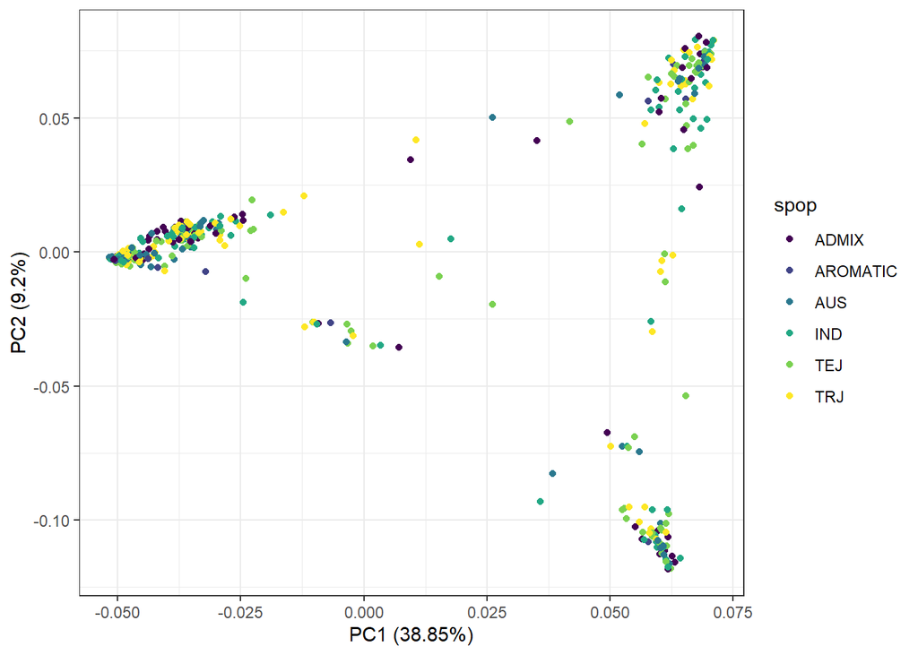

# 6 rMVP: Memory-efficient, Visualization-enhanced, and Parallel-accelerated Genome-Wide Association Study

## 6.1 Import data

```
## Preparing data for MVP...
## Reading file...
## inds: 413    markers: 36901
## Loading genotype at a step of 10000...
## Preparation for GENOTYPE data is done within 3s
## 413 common individuals between phenotype and genotype.
## Preparation for PHENOTYPE data is Done within 0s
## Imputing...
## Impute Genotype File is done!
## MVP data prepration accomplished successfully!
```

## 6.2 Kinship

```
## Computing GRM for 413 individuals using 36901 markers with a step of 10000
## Deriving relationship matrix successfully
## Preparation for Kinship matrix is done!
## An object of class "big.matrix"
## Slot "address":
## <pointer: 0x0000019bfd6c5b90>
```

## 6.3 Data input

## 6.4 GWAS

Nota: Para este analsis se uso la variable “Flowering.time.at.Arkansas”

[output not shown]

[output cut: 112 more lines]

```
Multraits_Rectangular Plotting...(finished 98%)
Multraits_Rectangular Plotting...(finished 100%)
## Multracks_QQ Plotting Flowering.time.at.Arkansas.GLM
## Multracks_QQ Plotting Flowering.time.at.Arkansas.MLM
## Multracks_QQ Plotting Flowering.time.at.Arkansas.FarmCPU
## Multraits_QQ Plotting Flowering.time.at.Arkansas.GLM
## Multraits_QQ Plotting Flowering.time.at.Arkansas.MLM
## Multraits_QQ Plotting Flowering.time.at.Arkansas.FarmCPU
## Results are stored at Working Directory: mvp/gwas
## End: 2025-05-01 11:16:41 -05
## Total running time: 23s
## ===================== MVP ACCOMPLISHED =====================
##             used  (Mb) gc trigger   (Mb)  max used   (Mb)
## Ncells   3371403 180.1    6239737  333.3   4908737  262.2
## Vcells 107425557 819.6  176550228 1347.0 176550007 1347.0
```

## 6.5 PCA

```
## Computing GRM for 413 individuals using 36901 markers with a step of 10000
## Deriving relationship matrix successfully
## Eigen Decomposition on GRM
## Deriving PCs successfully
## PCA plot2d
```

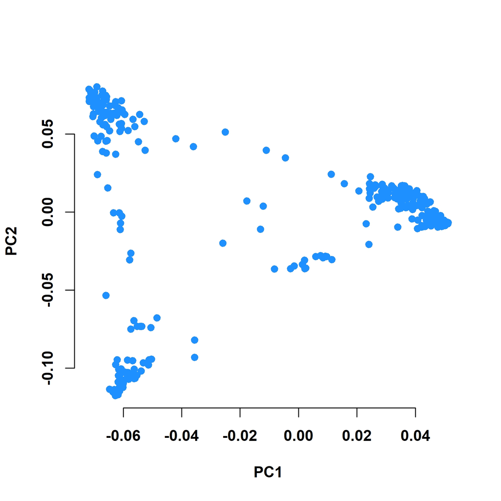

## 6.6 SNP density-plot

```
## SNP_Density Plotting
```

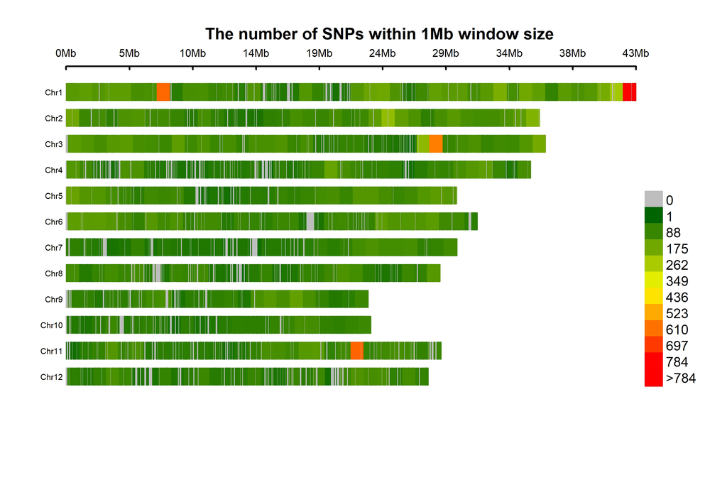

## 6.7 Phenotype distribution

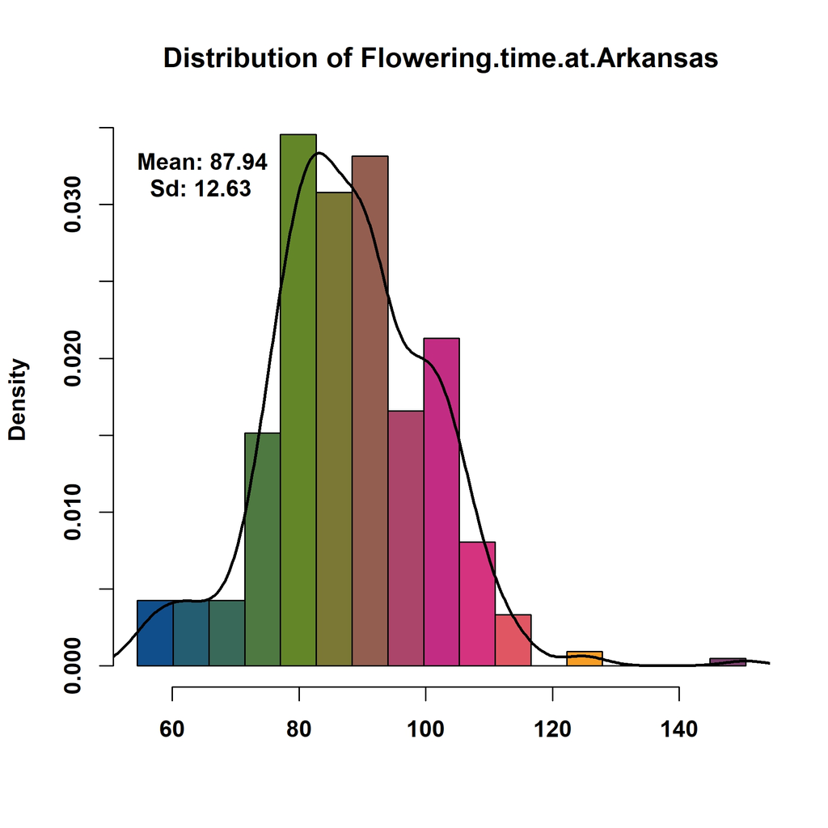

## 6.8 Manhatan

[output not shown]

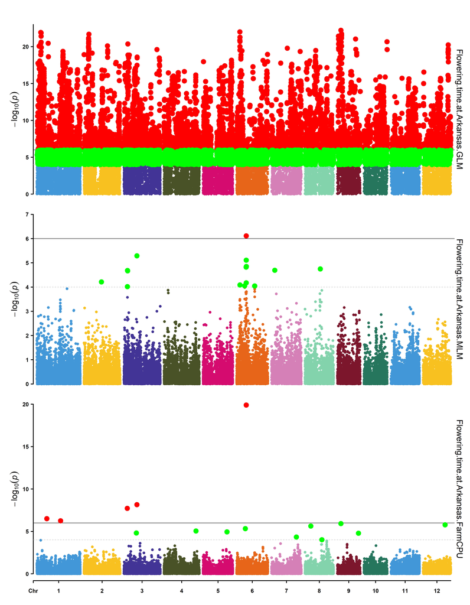

- **Interpretacion con el modelo GLM:** *Se identificaron 9202 SNPs en todo el genoma que pueden tener asoscion con el tiempo de floración (Ver el resultado: Flowering.time.at.Arkansas.GLM_signals.csv).*
- **Interpretacion con el modelo MLM**: *El SNP id6006118, ubicado en el cromosoma 6 en la posición 9,651,785, muestra una asociación estadísticamente significativa con el tiempo de floración en Arkansas (p = 7.77×10⁻⁷), según un modelo MLM. El alelo alternativo T, con una frecuencia menor (MAF) de 12.7%, está asociado con un aumento de 5.74 unidades en el tiempo de floración. Este resultado sugiere que este SNP podría estar vinculado a una región genómica que influye significativamente en este rasgo fenotípico (Ver el resultado: Flowering.time.at.Arkansas.MLM_signals.csv).*
- **Interpretacion con el modelo FarmCPU:** *Identificó varios SNPs significativamente asociados con el tiempo de floración en Arkansas. Destaca el **SNP id6006118** en el **cromosoma 6**, con un **efecto positivo de 8.59** días y un p-valor altamente significativo (**1.27×10⁻²⁰**), lo que sugiere una fuerte influencia sobre el rasgo. También se identificó el **SNP id3006754** en el **cromosoma 3** con un gran efecto positivo (**12.85**) y una baja frecuencia alélica (MAF = 0.008), indicando un posible alelo raro de gran impacto. Otros SNPs relevantes incluyen **id3001824**, **id1013613**, **id1007272** y **id9000871**, con efectos tanto positivos como negativos, y p-valores entre **10⁻⁶ y 10⁻⁸**, lo que refuerza su potencial implicación en la regulación del tiempo de floración. Estos hallazgos ofrecen candidatos prometedores para estudios funcionales y selección genómica en programas de mejoramiento(Ver el resultado: Flowering.time.at.Arkansas.FarmCPU_signals.csv).*

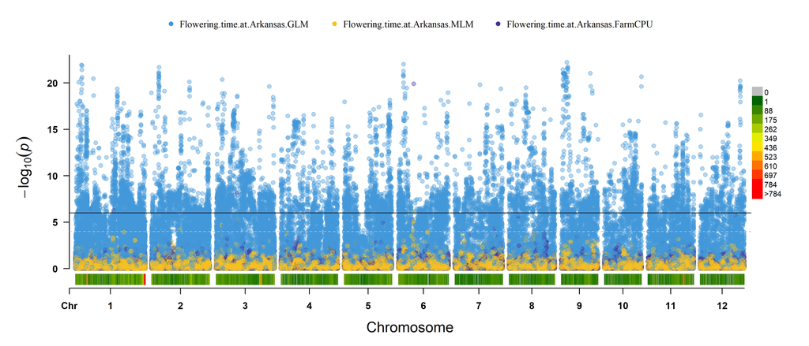

## 6.9 Q-Q plot

```
## Multracks_QQ Plotting Flowering.time.at.Arkansas.GLM
## Multracks_QQ Plotting Flowering.time.at.Arkansas.MLM
## Multracks_QQ Plotting Flowering.time.at.Arkansas.FarmCPU
## Multraits_QQ Plotting Flowering.time.at.Arkansas.GLM
## Multraits_QQ Plotting Flowering.time.at.Arkansas.MLM
## Multraits_QQ Plotting Flowering.time.at.Arkansas.FarmCPU
## png
##   2
```

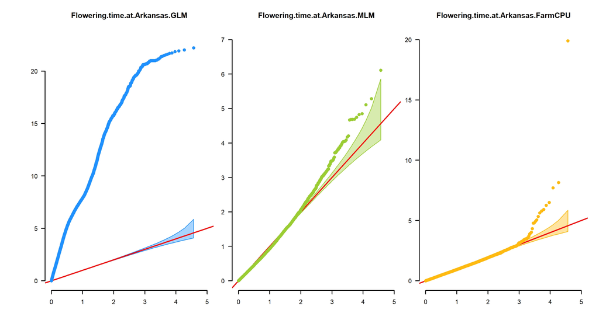

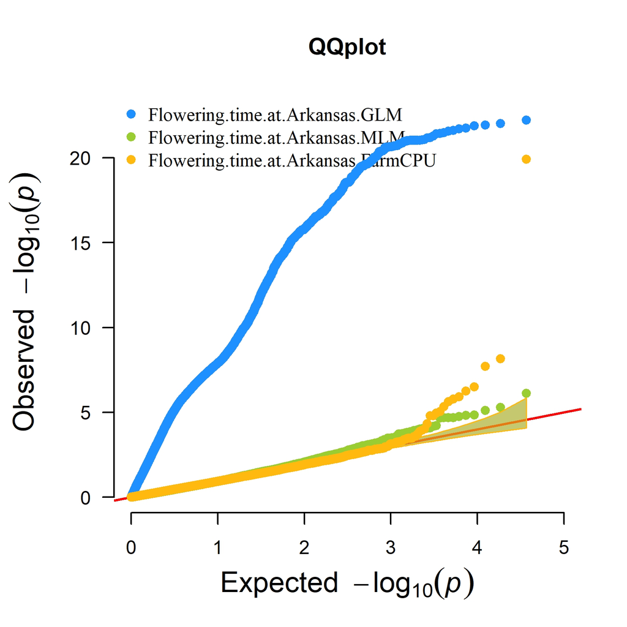